# RaceID/StemID/VarID reference manual

To check if the mean-dependence of the variance has been successfully removed by the normalization, the Pearson residuals can be plotted as a function of the mean:

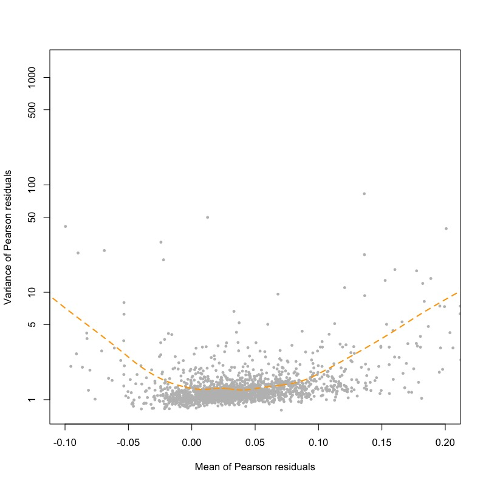

```r
plotPearsonRes(res,log=TRUE,xlim=c(-.1,.2))
```

The number of PCs selected based on the elbow criterion can be inspected by plotting the percentage variability explained by each principle component:

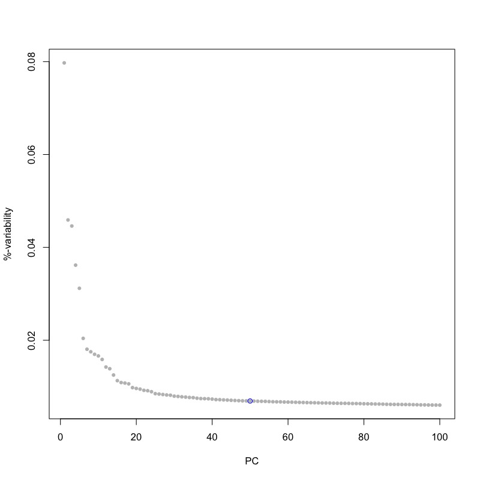

```r
plotPC(res)
```

Alternatively, the difference between the percentage variability explained by PC i and PC i + 1 can be plotted on a logarithmic scale:

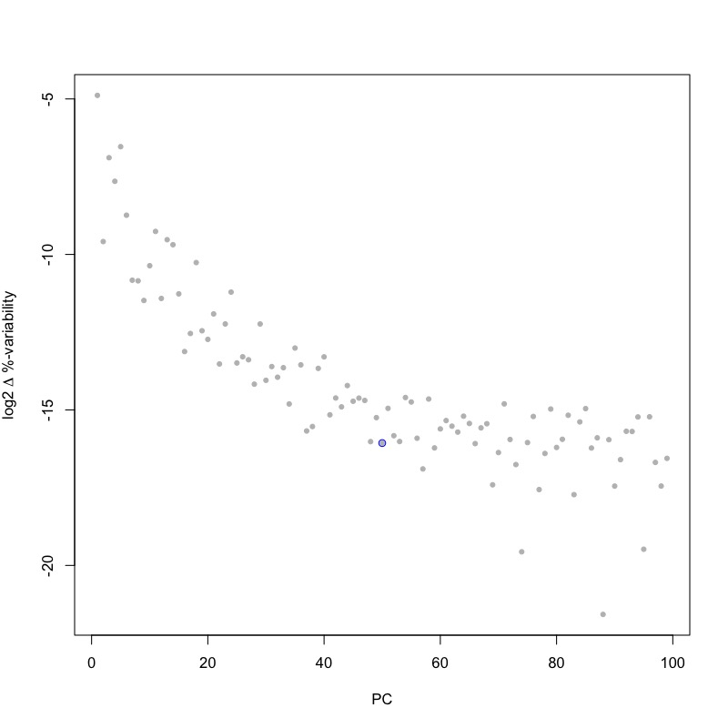

```r
plotPC(res,logDiff=TRUE)
```

The pruned k nearest neighbour information can be used as input for graph inference, Louvain clustering, and the derivation of a Fruchterman-Rheingold graph layout:

```r
cl <- graphCluster(res,pvalue=0.01)
```

Alternatively, community detection can be performed with the Leiden algorithm at variying resolution. However, the leiden package requires preinstallation of python libraries (https://cran.r-project.org/package=leiden). This can be done, e.g., by using python reticulate.

```r
install.packages("reticulate")
reticulate::use_python("/usr/bin/python3", required=TRUE)
#confirm that leiden, igraph, and python are available (should return TRUE).
reticulate::py_module_available("leidenalg") && reticulate::py_module_available("igraph")
reticulate::py_available()
```

With this `graphCluster` can be run using leiden clustering at defined resolution:

```r
cl <- graphCluster(res,pvalue=0.01,use.leiden=TRUE,leiden.resolution=1.5)
```

The function returns a list of three components: a vector `partition` with a clustering partition, a data.frame `fr` containing a Fruchterman-Rheingold layout computed from the pruned k nearest neighbour graph, and an integer number `residual.cluster`. If clusters with less than `min.size` (input parameter to `graphCluster`) were obtained, all these clusters are aggregated into the cluster with the largest cluster number in the partition. If this aggregation was done, the cluster nuber is stored in `residual.cluster` (which is `NULL` otherwise). By setting the `use.weights` argument of `graphCluster` to `TRUE` (default), clustering can be performed on the pruned knn graph with weighted links, where weights correspond to the link probabilities. This may lead to the emergence of too many clusters (which could happen, e.g., due to variability in the link probabilities when integrating different experimental batches). In this case, the `use.weights` parameter can be set to `FALSE`, and clustering is performed on a pruned knn graph with equal weights for all links. The `pvalue` parameter determines the probability cutoff for link pruning, i.e., links with probabilities lower than `pvalue` are removed.

To visualize the clustering with the help of RaceID, the `SCseq` object can be updated with the results:

```r
sc <- updateSC(sc,res=res,cl=cl)
```

This function call will initialize the `cpart` and the `cluster$kpart` slots with the clustering partition in `cl$partition`, and the `fr` slot with the Fruchterman-Rheingold layout.

The clustering can readily be inspected in the Fruchterman-Rheingold layout:

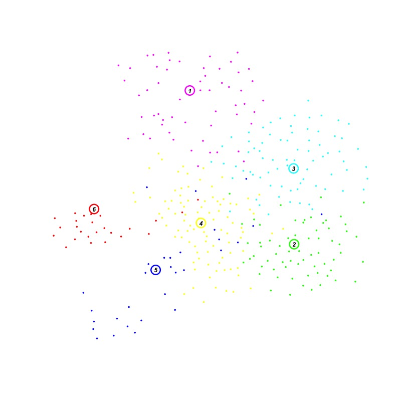

```r
plotmap(sc,fr=TRUE)
```

After computing a t-SNE map, the clustering can be also be visualized in t-SNE space:

```r
sc <- comptsne(sc,perplexity=50)
plotmap(sc)
```

[output not shown]

Alternatively, a umap representation can be computed for visualization:

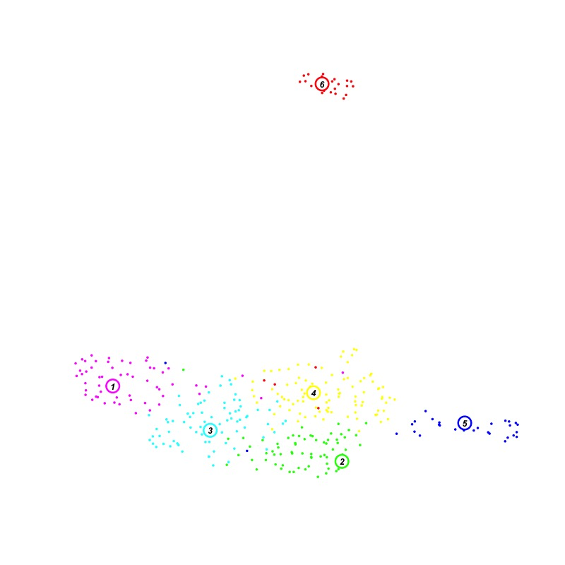

```r
sc <- compumap(sc,min_dist=0.5)
plotmap(sc,um=TRUE)
```

The pruned k nearest neighbour graph allows the derivation of transition probabilities between clusters, based on the remaining links connecting two clusters (at a minimum probability given by `pvalue`) and the inferred probabilities of these links:

```r
probs <- transitionProbs(res,cl,pvalue=0.01)
```

If RaceID is used for visualization and has been updated with the clustering using the `updateSC` function (see above), the transition probabilities can be visualized in the dimensional reduction representation (`fr=TRUE` for Fruchterman-Rheingold or `um=TRUE` for umap representation, default is t-SNE):

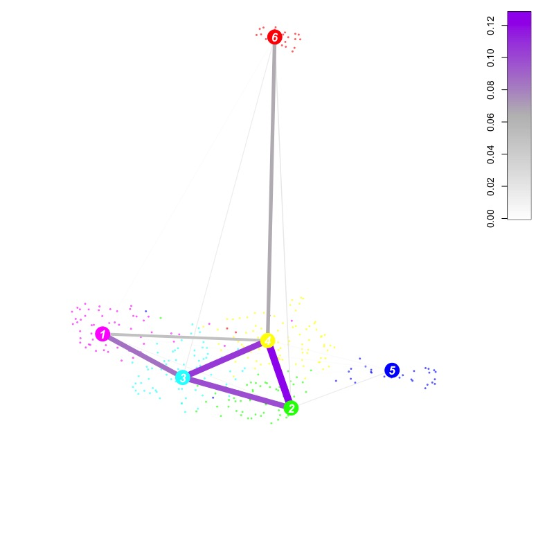

```r
plotTrProbs(sc,probs,um=TRUE)
```

The argument `prthr` allows discarding all links with a transition probability `<= prthr` and the th `cthr` argument sets a cluster size threshold. Only clusters with `> cthr` cells are shown.

The Individual neighbourhood of a cell, e.g, cell `i=20`, can be inspected with the `inspectKnn` function, which returns a list object with information on gene expression and outlier p-values across all original k nearest neighbours.

If the function is called with `plotSymbol=TRUE`, a dimensional reduction representation is returned (`um=TRUE` for umap), highlighting nearest neighbours and outliers which are subject to pruning:

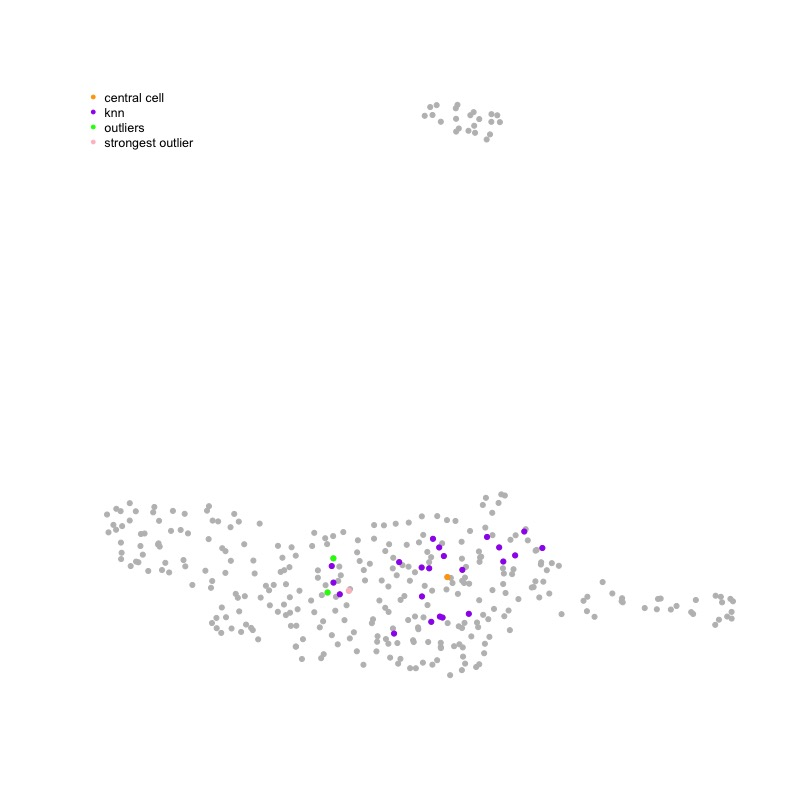

```r
nn <- inspectKNN(20,expData,res,cl,object=sc,pvalue=0.01,plotSymbol=TRUE,um=TRUE,cex=1)
```

One element of the returned list object is an outlier p-value across all k nearest neighbours:

```r
head(nn$pv.neighbours)
```

```
##           I5d_25 I5d_31 V5d_29 I5d_7 II5d_16 V5d_55 V5d_11       I5d_13 II5d_3
## Dmbt1          1      1      1     1       1      1      1 4.203964e-10      1
## Lgals2         1      1      1     1       1      1      1 1.001882e-01      1
## Cox5b          1      1      1     1       1      1      1 1.000000e+00      1
## Elf3           1      1      1     1       1      1      1 1.000000e+00      1
## Serpinb6a      1      1      1     1       1      1      1 1.000000e+00      1
## Ndufs8         1      1      1     1       1      1      1 1.000000e+00      1
##           III5d_2 II5d_43 I5d_11 IV5d_16 V5d_44 V5d_48 V5d_26 I5d_71 I5d_9
## Dmbt1           1       1      1       1      1      1      1      1     1
## Lgals2          1       1      1       1      1      1      1      1     1
## Cox5b           1       1      1       1      1      1      1      1     1
## Elf3            1       1      1       1      1      1      1      1     1
## Serpinb6a       1       1      1       1      1      1      1      1     1
## Ndufs8          1       1      1       1      1      1      1      1     1
##             I5d_61 III5d_67   II5d_44     III5d_91 II5d_72 V5d_16       V5d_96
## Dmbt1     0.391412        1 0.0310523 0.0008214995       1      1 1.577005e-11
## Lgals2    1.000000        1 1.0000000 0.1276183067       1      1 6.164142e-02
## Cox5b     1.000000        1 1.0000000 1.0000000000       1      1 1.000000e+00
## Elf3      1.000000        1 1.0000000 1.0000000000       1      1 1.000000e+00
## Serpinb6a 1.000000        1 1.0000000 1.0000000000       1      1 1.000000e+00
## Ndufs8    1.000000        1 1.0000000 1.0000000000       1      1 1.000000e+00
##               III5d_87
## Dmbt1     0.0002871395
## Lgals2    1.0000000000
## Cox5b     1.0000000000
## Elf3      1.0000000000
## Serpinb6a 1.0000000000
## Ndufs8    1.0000000000
```

Another element contains the corresponding normalized gene expression counts:

```r
head(nn$expr.neighbours)
```

```
##             I5d_25   I5d_31   V5d_29    I5d_7  II5d_16    V5d_55   V5d_11
## Dmbt1     0.000000 0.000000 1.001958 0.000000 1.001958 16.521861 2.007853
## Lgals2    4.031579 6.071431 8.127667 6.071431 5.049473 20.824484 6.071431
## Cox5b     3.017717 5.049473 8.127667 4.031579 3.017717 14.397368 3.017717
## Elf3      0.000000 3.017717 4.031579 0.000000 1.001958  0.000000 0.000000
## Serpinb6a 0.000000 2.007853 0.000000 0.000000 2.007853  2.007853 0.000000
## Ndufs8    0.000000 1.001958 1.001958 0.000000 0.000000  0.000000 0.000000
##              I5d_13    II5d_3  III5d_2   II5d_43    I5d_11   IV5d_16    V5d_44
## Dmbt1     58.126707 15.457411 0.000000  6.071431  7.097484 12.290360  2.007853
## Lgals2    49.489744 16.521861 0.000000 20.824484 13.341696 10.200553 12.290360
## Cox5b     11.243324  9.162012 0.000000 11.243324  8.127667  6.071431  3.017717
## Elf3       2.007853  4.031579 2.007853  3.017717  5.049473  3.017717  1.001958
## Serpinb6a  0.000000  3.017717 0.000000  0.000000  2.007853  0.000000  1.001958
## Ndufs8     2.007853  0.000000 1.001958  4.031579  2.007853  0.000000  2.007853
##             V5d_48   V5d_26   I5d_71    I5d_9    I5d_61 III5d_67   II5d_44
## Dmbt1     7.097484 2.007853 0.000000 2.007853 18.664133 0.000000 24.099582
## Lgals2    8.127667 6.071431 5.049473 6.071431 25.200659 1.001958 24.099582
## Cox5b     5.049473 0.000000 7.097484 6.071431  9.162012 2.007853  6.071431
## Elf3      2.007853 1.001958 1.001958 0.000000  8.127667 3.017717  3.017717
## Serpinb6a 0.000000 0.000000 1.001958 1.001958  1.001958 0.000000  2.007853
## Ndufs8    1.001958 0.000000 0.000000 0.000000  2.007853 0.000000  3.017717
##            III5d_91   II5d_72   V5d_16    V5d_96  III5d_87        mu        sd
## Dmbt1     30.778221  6.071431 0.000000 64.479391 33.043723 2.5055710 2.1985583
## Lgals2    48.279339 14.397368 1.001958 50.705898 18.664133 7.9128263 5.4987806
## Cox5b     13.341696  8.127667 2.007853 27.417123  7.097484 4.9477707 3.7253325
## Elf3       4.031579  2.007853 0.000000 10.200553  1.001958 1.0414053 1.1874937
## Serpinb6a  2.007853  1.001958 0.000000  6.071431  1.001958 0.4475373 0.7031934
## Ndufs8     3.017717  4.031579 1.001958  7.097484  2.007853 0.7428016 0.9551797
##                     pv
## Dmbt1     1.577005e-11
## Lgals2    6.164142e-02
## Cox5b     1.000000e+00
## Elf3      1.000000e+00
## Serpinb6a 1.000000e+00
## Ndufs8    1.000000e+00
```

If the same function is executed with `plotSymbol=FALSE`, the local mean-variance dependence is plotted along with a loess-regression, a second order polynomial fit (used for pruning), and the background model of the local variability (used for biological noise inference, see below):

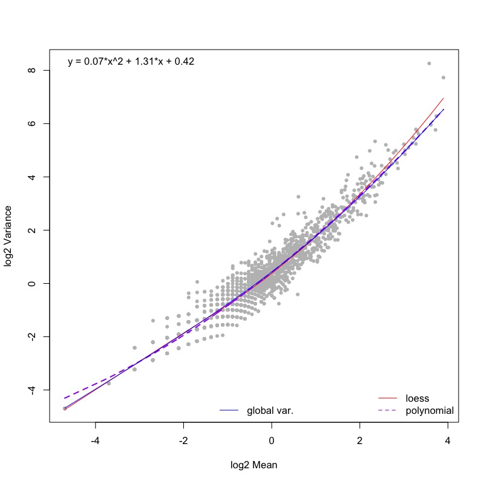

```r
nn <- inspectKNN(20,expData,res,cl,object=sc,pvalue=0.01,plotSymbol=FALSE)
```

Alternatively, the coefficient of variation (CV) can be plotted with the same model fits:

```r
nn <- inspectKNN(20,expData,res,cl,object=sc,pvalue=0.01,plotSymbol=FALSE,cv=TRUE)
```

[output not shown]

The inference of homogenous local neighbourhoods, given by a cell and its remaining nearest neighbours after pruning, permits the computation of local quantities across such sets of similar cells. To investigate the dynamics of gene expression noise across cell states, we derive local estimates of gene expression variability. The systematic dependence of gene expression variance on the mean expression is a central challenge for the derivation of differential variability between cell states. VarID2 solves this problem by deconvoluting binomial sampling noise, cell-to-cell variability in total transcript counts (as a consequence of cell-to-cell variability in sequencing efficiency, but also due to global biological variability in total RNA content, e.g., during different phases of the cell cycle), and residual variability, which we address as biological noise. This deconvolution is achieved by fitting a Gamma distribution to the local disrtibution of total transcript counts, yielding a technical noise paramater `rt` for each central cell, followed by a maximum a posterior inference of the reidual variability, i.e., biological noise, `epsilon` for each gene in every neighbourhood. The local mean expression `mu` within each neighbourhood is computed as the average of non-normalized transcript count across pruned local neighbourhoods.

```r
x <- getFilteredCounts(sc,minexpr=5,minnumber=20)
noise <- compTBNoise(res,x,pvalue=0.01,gamma = 0.5,no_cores=1)
```

The most important argument of the `compTBNoise` is the `gamma` parameter which determines the strength of the prior for the suppression of spurious inflation of noise levels at low expression. The `p-value` argument again determines the link probability threshold for pruning. For neighbourhoods with zero transcript count noise estimates are replaced by `NA` in `noise$epsilon`.

The prior parameter `gamma` should be chosen such that the correlation between mean noise across cells and total UMI count per cell is minimal. This dependence can be analysed with the function `plotUMINoise`:

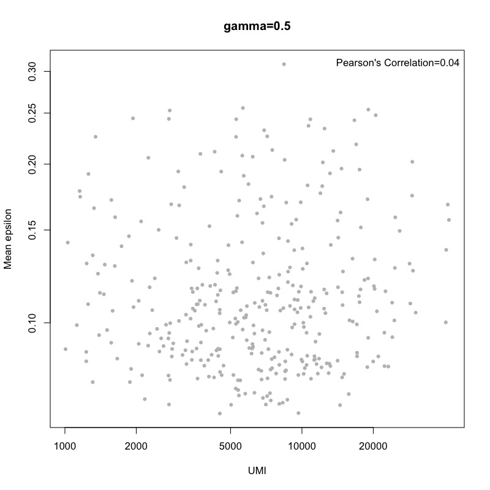

```r
plotUMINoise(sc,noise,log.scale=TRUE)
```

If a positive correlation is observed, `gamma` should be increased in order to weaken the prior. If the correlation is negative, `gamma` should be decreased in order to increase the strength of the prior.

The RaceID `SCseq` object can be updated with the biological noise estimates:

```r
sc <- updateSC(sc,res=res,cl=cl,noise=noise)
```

This initializes a slot `noise` of the `SCseq` object with a gene-by-cell matrix of the biological noise estimates `noise$epsilon`. The noise levels of a given gene (or group of genes), can then be visualized in the same way as gene expression with the help of RaceID functions.

Gene expression (on logarithmic scale):

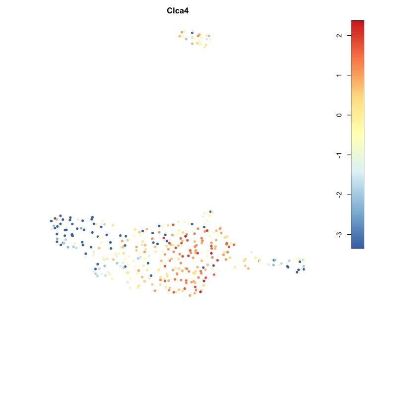

```r
plotexpmap(sc,"Clca4",logsc=TRUE,um=TRUE,cex=1)
```

Biological noise (on logarithmic scale):

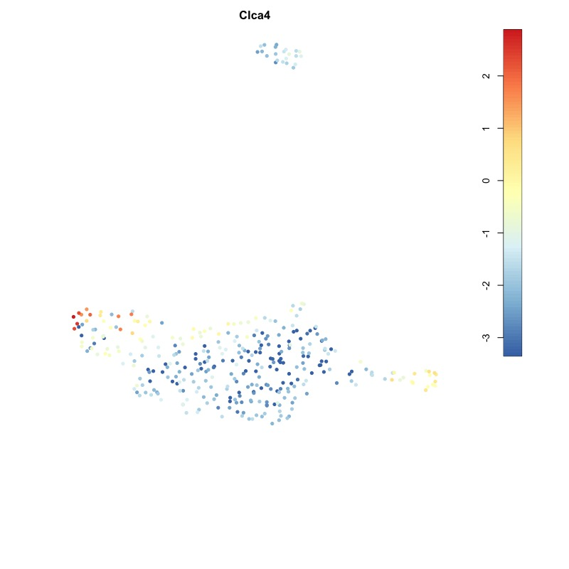

```r
plotexpmap(sc,"Clca4",logsc=TRUE,um=TRUE,noise=TRUE,cex=1)
```

This plot indicates that cluster 2 comprises Clca4+ intestinal stem cells.

A scatter plot of noise versus gene expression allows inspection of the dependence between noise and gene expression:

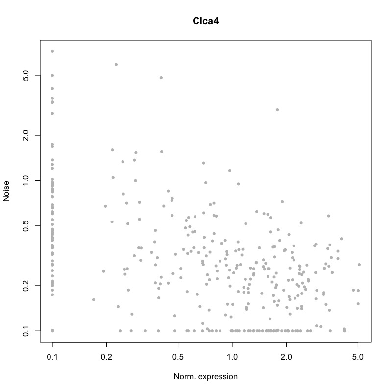

```r
plotExpNoise("Clca4",sc,noise,norm=TRUE,log="xy")
```

The biological noise can also be plotted in a cluster heatmap and directly compared to gene expression. After deriving a gene expression heatmap, the order of genes stored in `ph` (returned by the `pheatmap` function of the `pheatmap` package), can be applied to the noise heatmap in order to permit direct comparability:

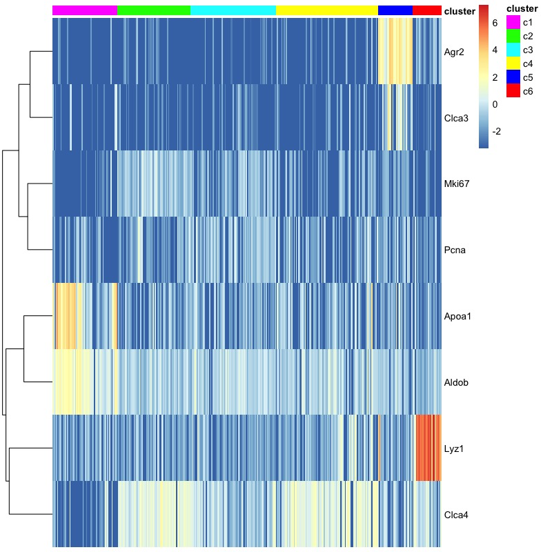

```r
genes <- c("Lyz1","Agr2","Clca3","Apoa1","Aldob","Clca4","Mki67","Pcna")
ph <- plotmarkergenes(sc,genes=genes,noise=FALSE)
```

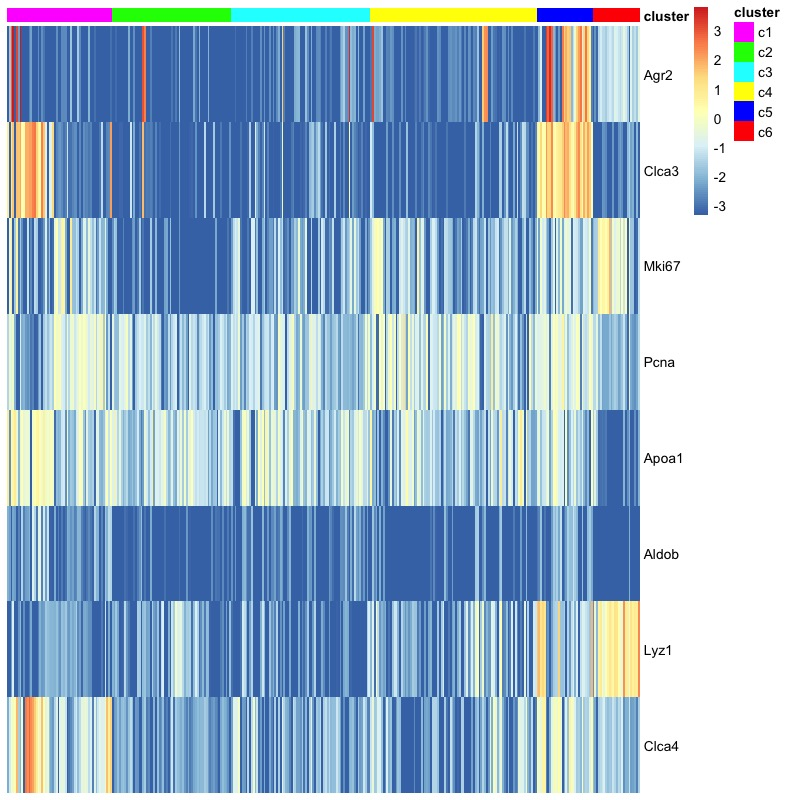

```r
plotmarkergenes(sc,genes=genes[ph$tree_row$order],noise=TRUE,cluster_rows=FALSE)
```

Based on marker gene expression, clusters 1, 5, and 6, can be annotated as enterocytes, goblet and Paneth cells. The gene expression can also be visualized in a dot plot highlighting the fraction of cells in a cluster expressing a gene (size of dots) together with the average expresson level (dot color):

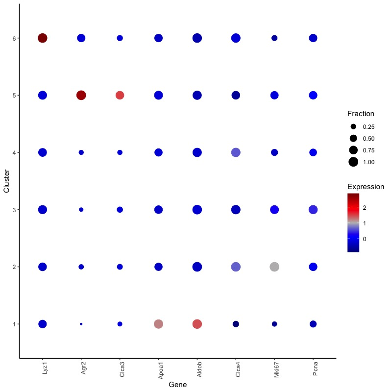

```r
fractDotPlot(sc, genes, zsc=TRUE)
```

With the clustering derived by `graphCluster` and the `noise` object returned by the `compTBNoise` function, genes with differential noise levels in a cluster (or a set of clusters) `set` versus a background set `bgr` (by default all clusters not in `set`) can be inferred:

```r
ngenes <- diffNoisyGenesTB(noise,cl,set=1,no_cores=1)
head(ngenes)
```

```
##           mu.set     mu.bgr     mu.all   eps.set    eps.bgr    eps.all   log2FC
## Alpi    2.621820  0.4346426  0.7970891 0.7578040 0.09111629 0.20159597 2.166197
## Rbp2    3.302158  0.3872477  0.8702899 0.4666415 0.03726573 0.10841943 2.045465
## Clca4   2.183234  8.8030572  7.7060579 1.1240327 0.20844378 0.36016995 1.988563
## Rpl3   13.834292 22.1688750 20.7877156 0.3703321 0.02425532 0.08160519 1.920372
## Clec2h  1.972938  0.2797050  0.5602980 0.5456636 0.07200037 0.15049313 1.908371
## Ces2a   2.067663  0.4751257  0.7390318 0.3474690 0.03352372 0.08554895 1.744692
##              pvalue
## Alpi   1.775718e-17
## Rbp2   4.309437e-15
## Clca4  5.774251e-08
## Rpl3   8.000818e-14
## Clec2h 1.822229e-14
## Ces2a  1.852172e-16
```

The output lists average (non-normalized) expression `mu` and noise levels `eps` for clusters in `set` and `bgr` as well as the log2 fold change in noise levels, `log2FC`, between `set` and `bgr` and a multiple testing-corrected p-value (Bonferroni correction, multiplied by the maximal number `knn` of nearest neighbours).

This functions applies a Wilcoxon test to compare variability in a cluster (or set of clusters) versus the remaining clusters or a given background set of clusters. To avoid spurious signals with small effect size, a uniform random variable (by default, from `[0:ps]` with `ps=0.1`) is added to the noise estimates.

The top varaible genes can be plotted in a heatmap:

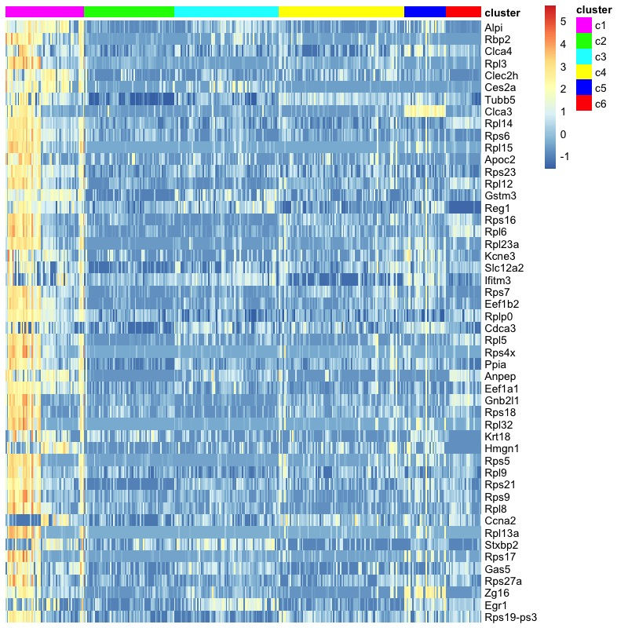

```r
genes <- head(rownames(ngenes),50)
ph <- plotmarkergenes(sc,genes=genes,noise=TRUE,cluster_rows=FALSE,zsc=TRUE)
```

One can also cluster the cells and/or genes in the heatmap based on the noise quantification:

```r
ph <- plotmarkergenes(sc,genes=genes,noise=TRUE,cluster_rows=TRUE,cluster_cols=TRUE)
```

[output not shown]

The gene expression itself can be represented with the same order of cells and genes by utilizing the `ph` output:

```r
plotmarkergenes(sc,genes=ph$tree_row$labels[ ph$tree_row$order ],noise=FALSE,cells=ph$tree_col$labels[ ph$tree_col$order ], order.cells=TRUE,cluster_rows=FALSE)
```

[output not shown]

It is also possible to order genes by their noise levels across a (set of) cluster or the entire dataset, if the `cl` argument is omitted:

```r
mgenes <- maxNoisyGenesTB(noise,cl=cl,set=3)
head(mgenes)
```

```
##     Reg3b   Tmem38b    Hspa1b    Hspa1a     H2afx     Reg3g
## 1.5410659 1.0669050 1.0629981 0.9270232 0.8132892 0.7873700
```

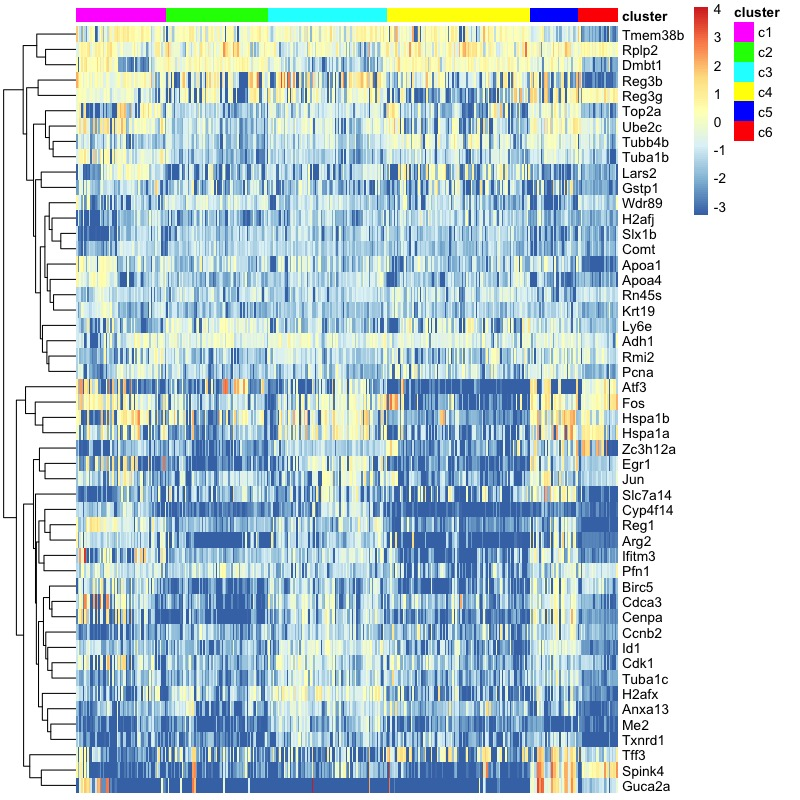

```r
plotmarkergenes(sc,genes=head(names(mgenes),50),noise=TRUE)
```

Differential noise between clusters in `set` and `bgr` can also be visualized as MA plot:

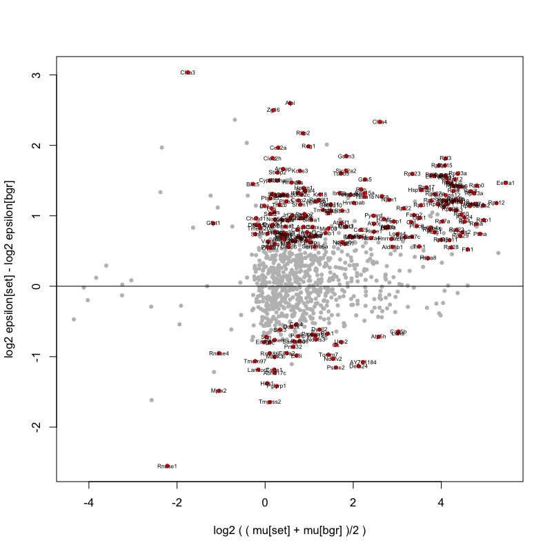

```r
ngenes <- diffNoisyGenesTB(noise, cl, set=1, bgr=c(2,4))
plotDiffNoise(ngenes)
```

For comparison, differentially expressed genes between the same groups can be inferred and visualized in a similar manner:

```r
dgenes <- clustdiffgenes(sc,1,bgr=c(2,4),pvalue=0.01)
plotdiffgenesnb(dgenes,xlim=c(-6,3))
```

[output not shown]

The distribution of gene expression (for individual genes or groups of genes) across a set of clusters can be visualized as violin plots:

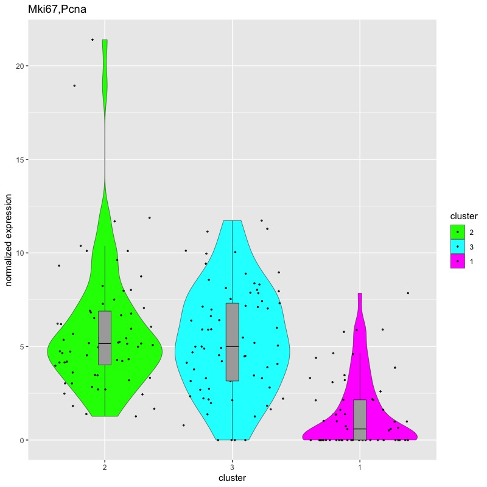

```r
violinMarkerPlot(c("Mki67","Pcna"),sc,set=c(2,3,1))
```

Similarly, the distribution of gene expression noise can be plotted:

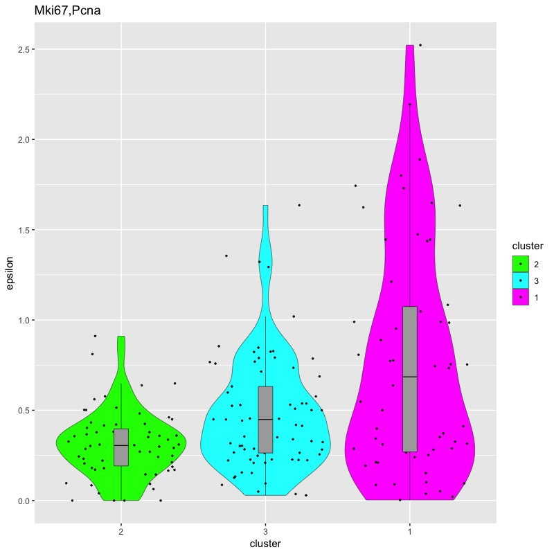

```r
violinMarkerPlot(c("Mki67","Pcna"),sc,noise,set=c(2,3,1))
```

To further investigate transcriptome variability and related quantities, the function `quantKnn` allows computation of average noise levels across cells, cell-to-cell transcriptome correlation, and total UMI counts.

```r
qn <- quantKnn(res, noise, sc, pvalue = 0.01, minN = 5, no_cores = 1)
```

These quantities can be inspected in the dimensional reduction representation, or as boxplots across cluster, with the level of a selected reference cluster highlighted as horizontal line. For instance, the Lgr5+ stem cell cluster 2 can be used as a reference:

```r
StemCluster <- 2
```

Average biological noise across all genes:

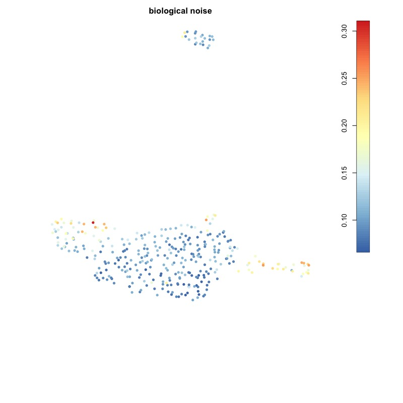

```r
plotQuantMap(qn,"noise.av",sc,um=TRUE,ceil=.6,cex=1)
```

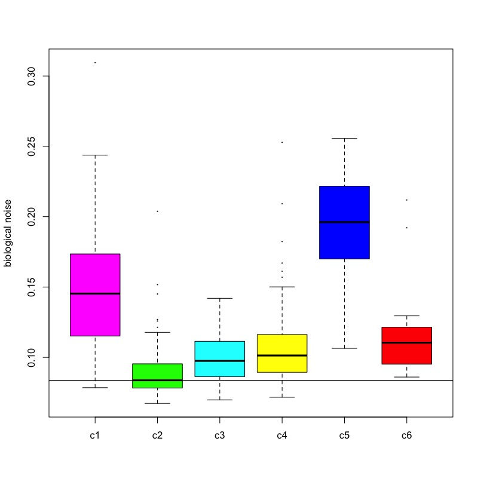

```r
plotQuantMap(qn,"noise.av",sc,box=TRUE,cluster=StemCluster)
```

Avergae Spearman's transcriptome correlation across all cells within pruned k nearest neighbourhoods:

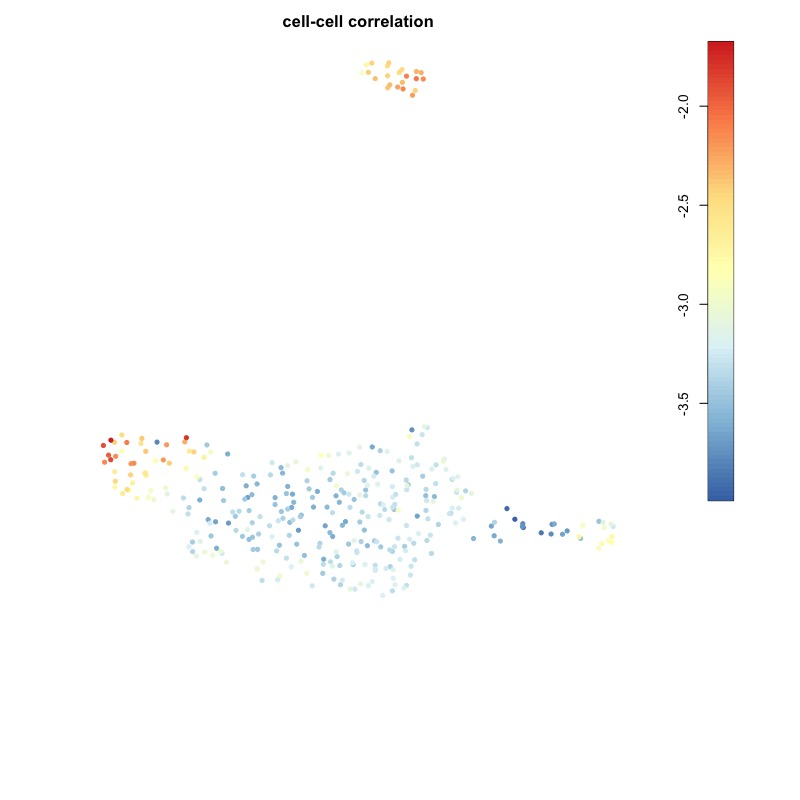

```r
plotQuantMap(qn,"local.corr",sc,um=TRUE,logsc=TRUE,cex=1)
```

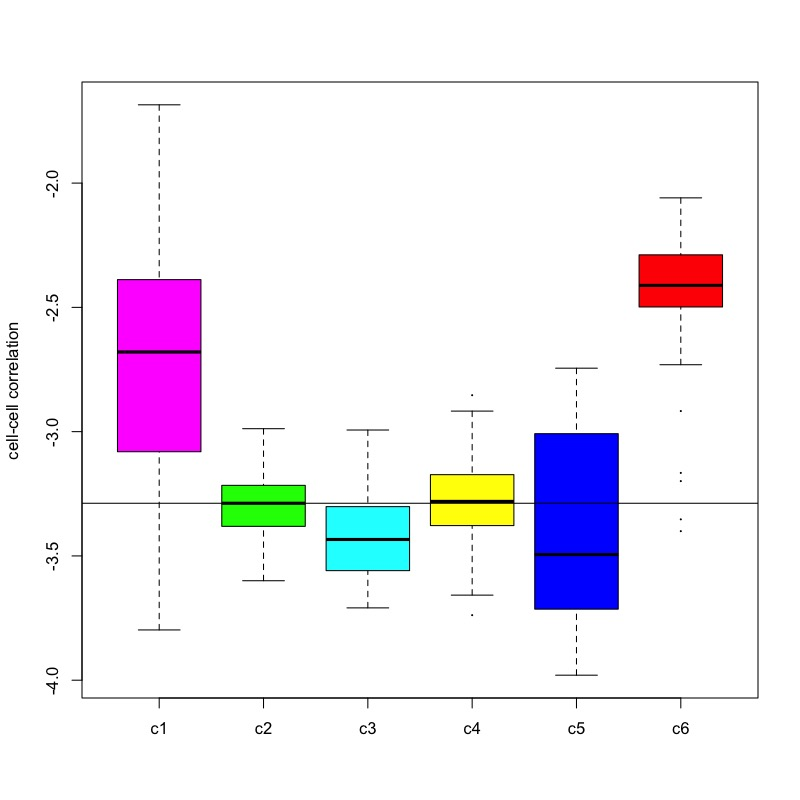

```r
plotQuantMap(qn,"local.corr",sc,box=TRUE,logsc=TRUE,cluster=StemCluster)
```

Total UMI count averaged across cells within pruned k nearest neighbourhoods:

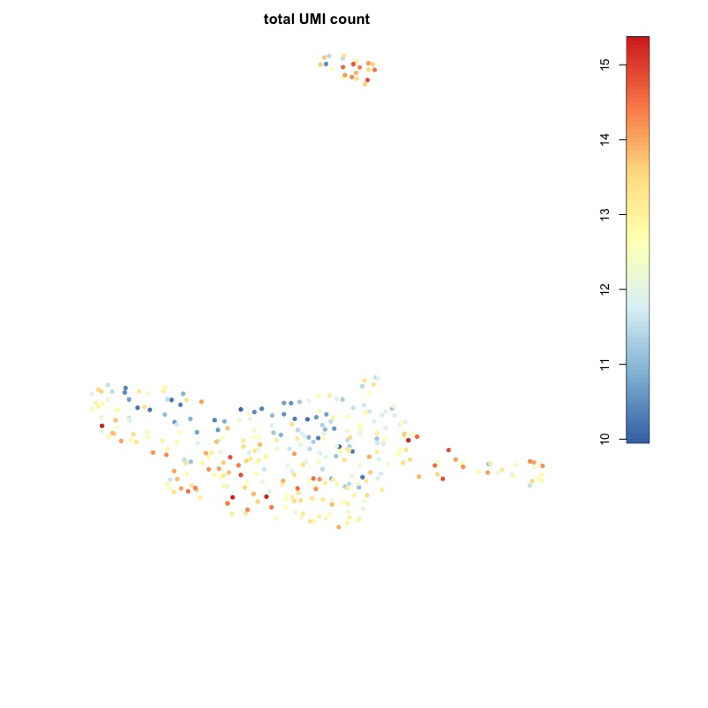

```r
plotQuantMap(qn,"umi",sc,um=TRUE,logsc=TRUE,cex=1)
```

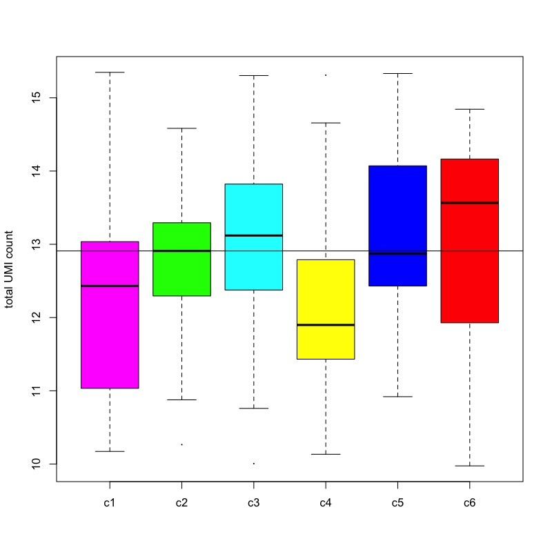

```r
plotQuantMap(qn,"umi",sc,box=TRUE,logsc=TRUE,cluster=StemCluster)
```

Dependencies between different quantities can be inspected in a scatter plot, highlighting a cluster of interest:

For instance, the dependency between biological noise and UMI counts:

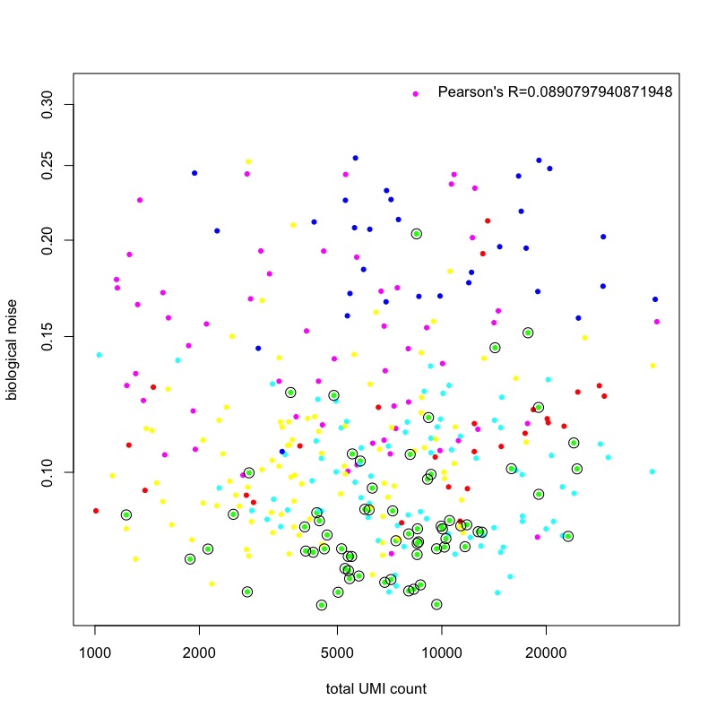

```r
plotQQ(qn,"umi","noise.av",sc,cluster=StemCluster,log="yx",cex=1)
```

A residual dependency of the noise estimate on the total UMI count may indicate that the prior is either not strong enough to suppress noise inflation at low expression (negative slope) or too strong (positive slope). In this case, the parameter `gamma` of the function `compTBNoise` should be increased or decreased, respectively.

Dependency between transcriptome correlation and average biological noise:

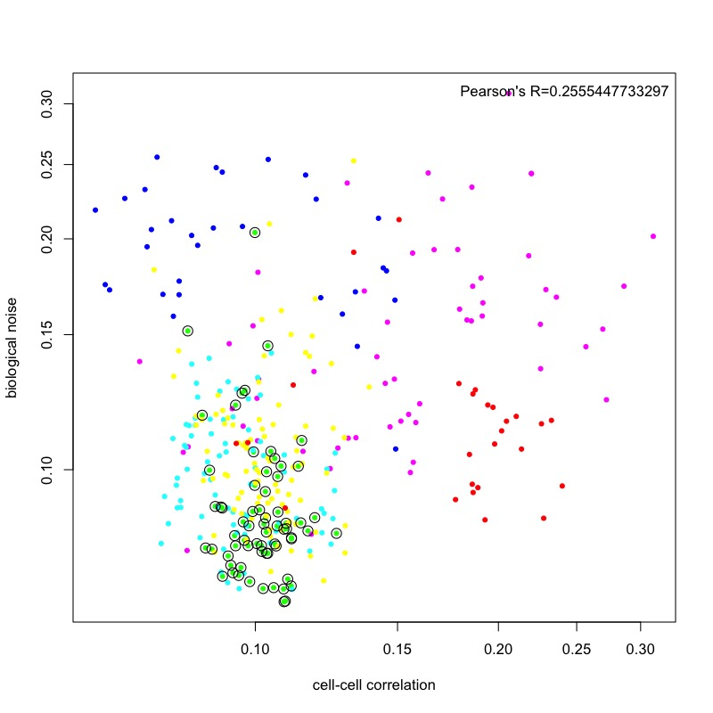

```r
plotQQ(qn,"local.corr","noise.av",sc,cluster=StemCluster,log="xy",cex=1)
```

To study dynamics of gene expression and biological noise during differentiation, VarID2 facilitates pseudo-time analysis. Selection of a linear trajectry connecting a defined set of clusters could be based on the transition probabilities obtained from VarID2.

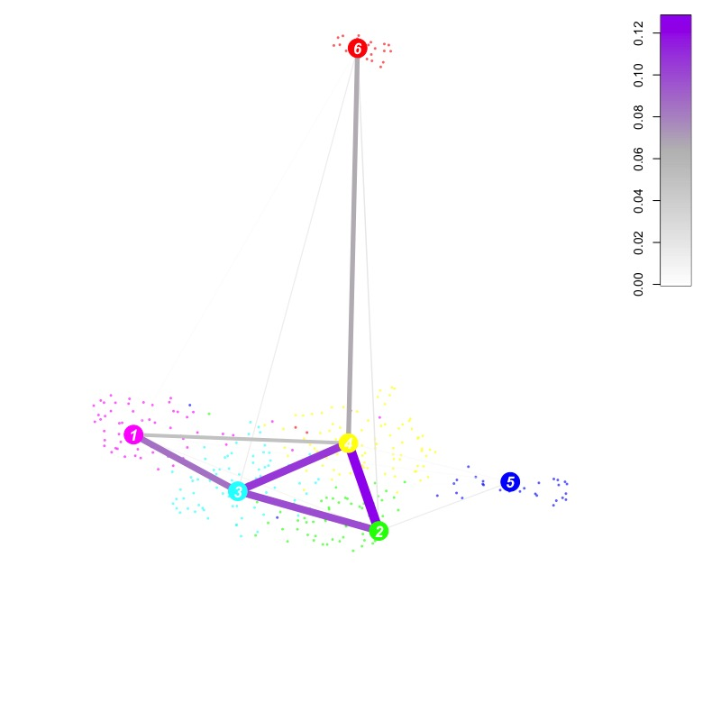

```r
plotTrProbs(sc,probs,um=TRUE)
```

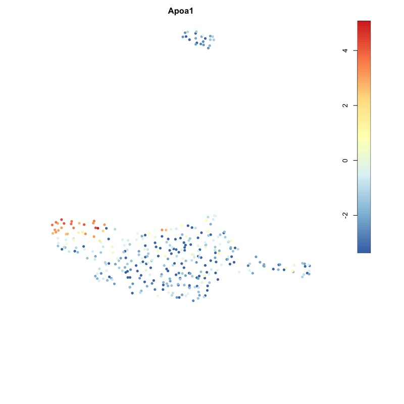

```r
plotexpmap(sc,"Apoa1",um=TRUE,cex=1,logsc=TRUE)
```

```r
# ordered set of clusters on the trajectory
set <- c(2,3,1)
# if slingshot is available, run with useSlingshot=TRUE (default)
pt <- pseudoTime(sc,m="umap",set=set,useSlingshot=FALSE)
```

Inferred pseudo-time can be highlighted in the inferred dimensional reduction representation:

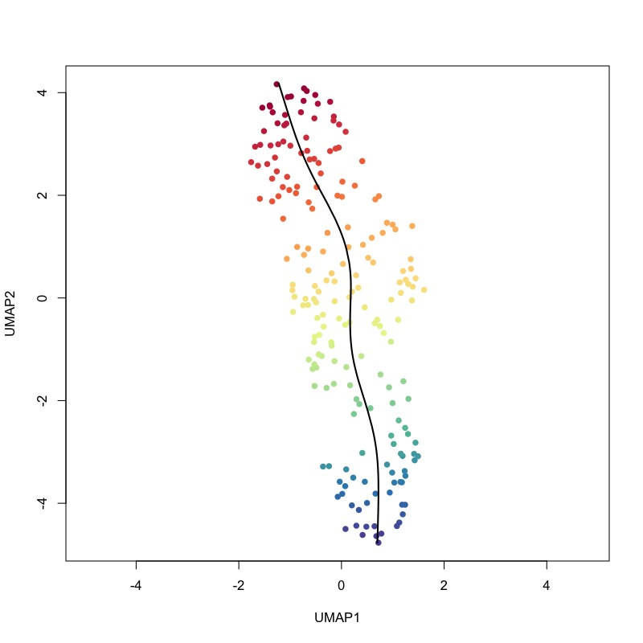

```r
plotPT(pt,sc,clusters=FALSE)
```

The trajectory can also be overlaid with the cluster annotation:

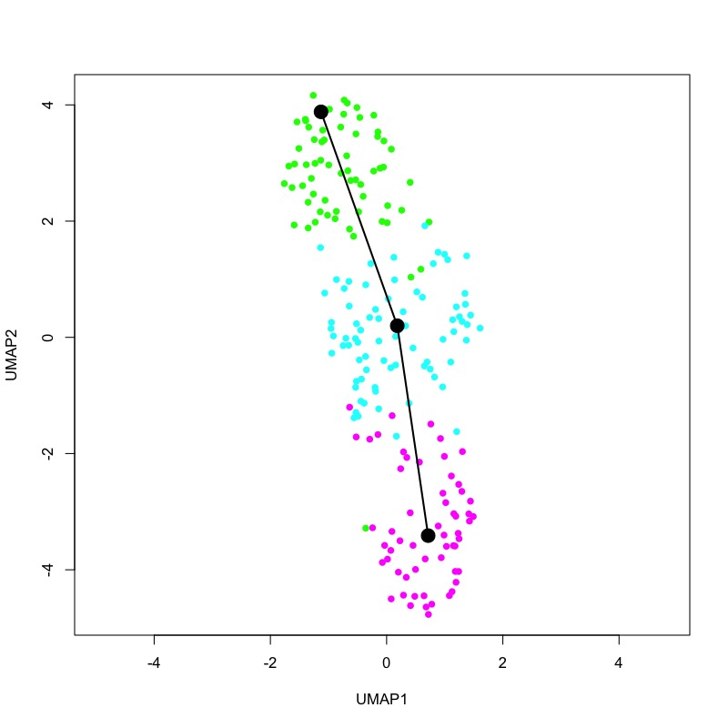

```r
plotPT(pt,sc,clusters=TRUE,lineages=TRUE)
```

With the derived pseudo-time a filtered count matrix with cells ordered by pseudo-time can be obtained:

```r
fs <- extractCounts(sc,minexpr=5,minnumber=20,pt=pt)
```

Using methods from the `FateID` package, pseudo-time expression profiles can be derived by self-organizing maps (SOM) and grouped into modules:

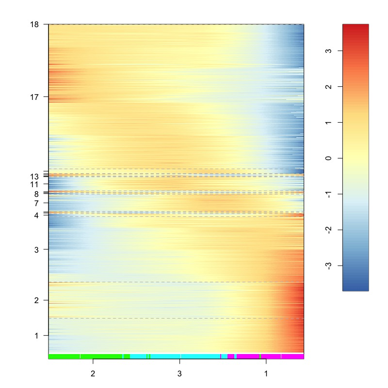

```r
library(FateID)
s1d   <- getsom(fs,nb=50,alpha=1)
ps    <- procsom(s1d,corthr=.85,minsom=0)

part  <- pt$part
ord   <- pt$ord

plotheatmap(ps$all.z, xpart=part[ord], xcol=sc@fcol, ypart=ps$nodes, xgrid=FALSE, ygrid=TRUE, xlab=TRUE)
```

Individual pseudo-time expression profiles can be plotted for genes of interest, e.g.,

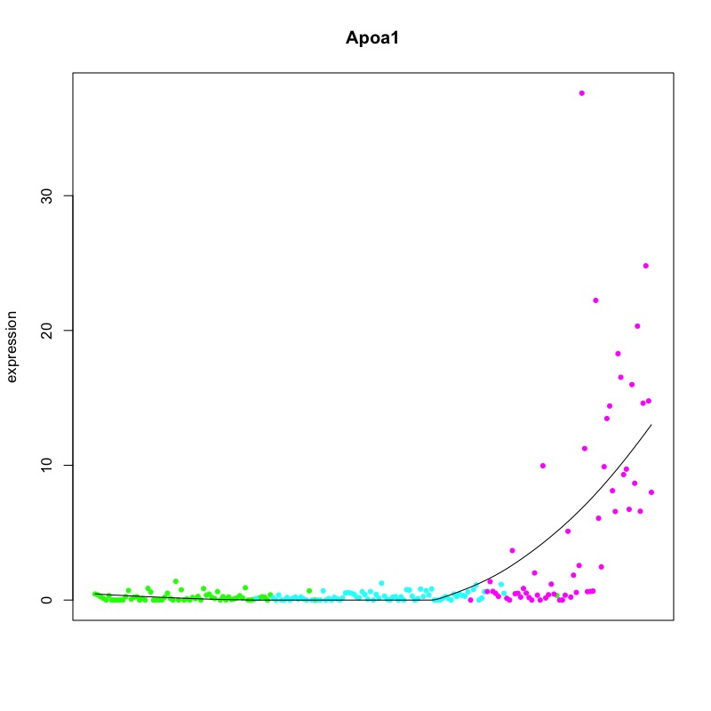

```r
plotexpression(fs,y=part,g="Apoa1",n=ord,col=sc@fcol,cex=1,alpha=1)
```

It is also possible to plot profiles for a group of genes into the same window:

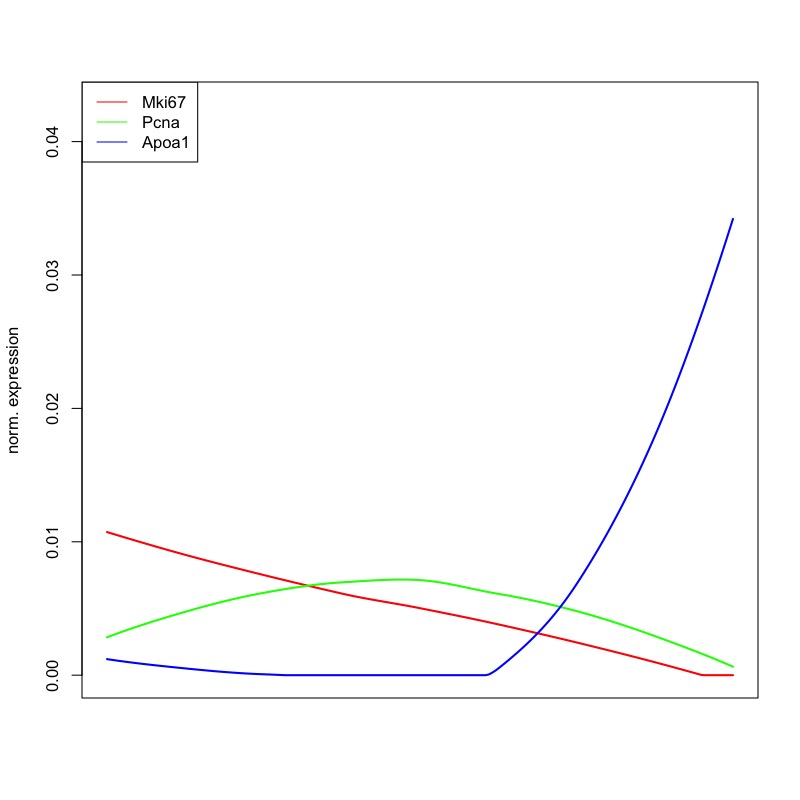

```r
genes <- c("Mki67","Pcna","Apoa1")
plotexpressionProfile(fs,y=part,g=genes,n=ord,alpha=1,col=rainbow(length(genes)),lwd=2)
```

From the SOM all genes within a given module, e.g., module 1, can be extracted:

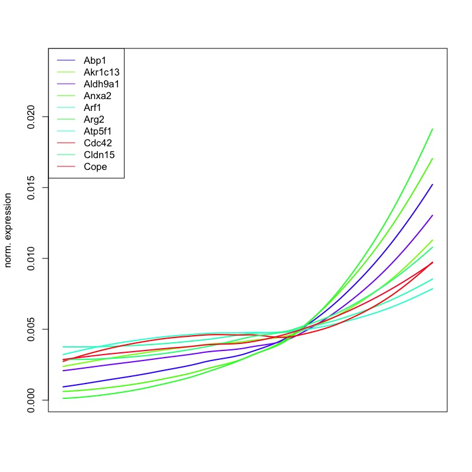

```r
genes <- getNode(ps,1)
plotexpressionProfile(fs,y=part,g=head(genes,10),n=ord,alpha=1,lwd=2)
```

Similarly, gene modules with correlated noise profiles can be derived:

```r
fsn    <- extractCounts(sc,minexpr=5,minnumber=20,pt=pt,noise=TRUE)
s1dn   <- getsom(fsn,nb=25,alpha=1)
psn    <- procsom(s1dn,corthr=.85,minsom=0)
```

```r
plotheatmap(psn$all.z, xpart=part[ord], xcol=sc@fcol, ypart=ps$nodes, xgrid=FALSE, ygrid=TRUE, xlab=TRUE)
```

[output not shown]

Noise profiles of individual genes or groups of genes:

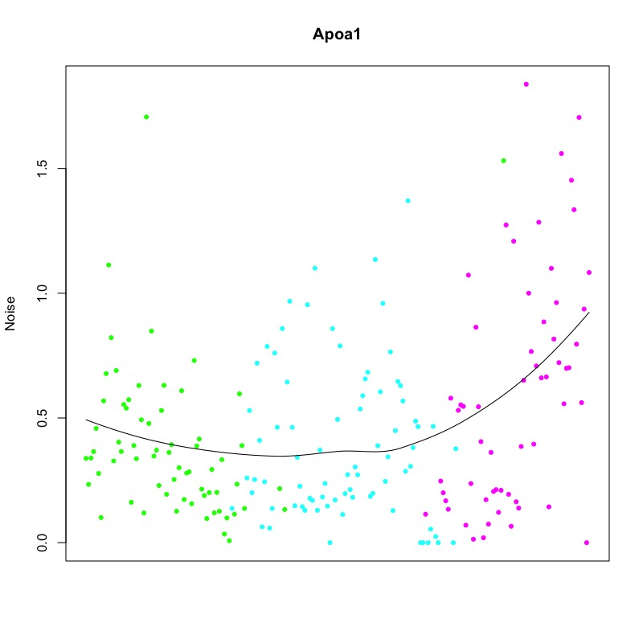

```r
plotexpression(fsn,y=part,g="Apoa1",n=ord, col=sc@fcol,cex=1,alpha=1,ylab="Noise")
```

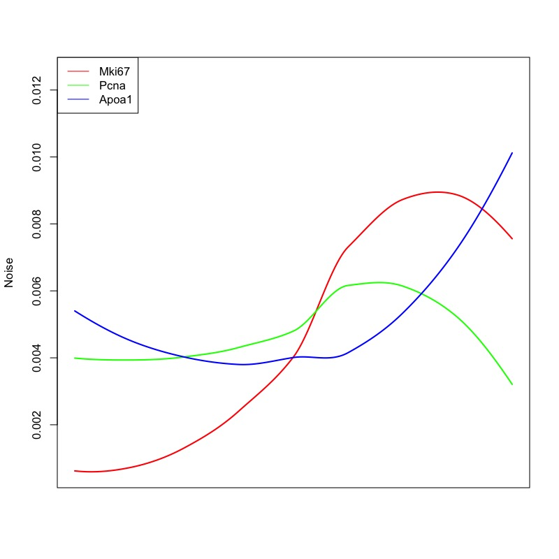

```r
genes <- c("Mki67","Pcna","Apoa1")
plotexpressionProfile(fsn,y=part,g=genes,n=ord,alpha=1,col=rainbow(length(genes)),lwd=2,ylab="Noise")
```

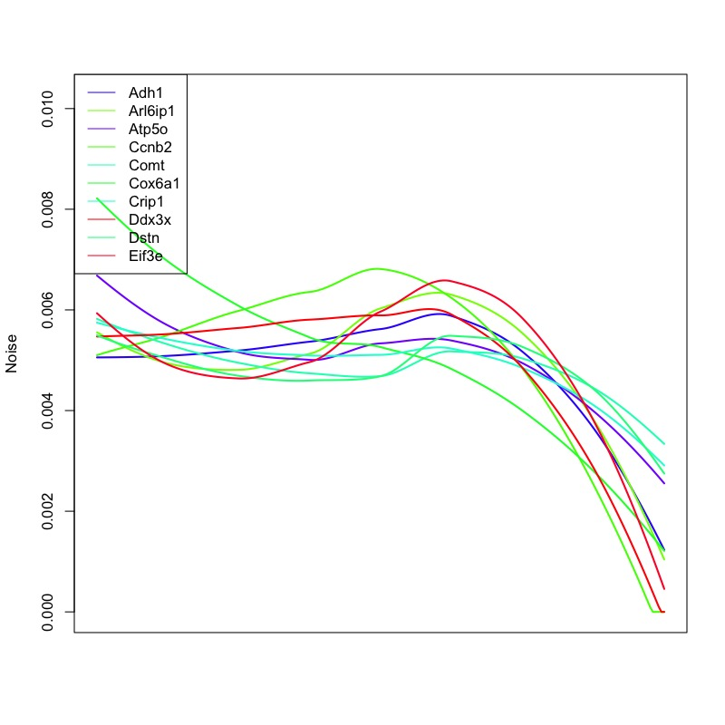

```r
genes <- getNode(psn,1)
plotexpressionProfile(fsn,y=part,g=head(genes,10),n=ord,alpha=1,lwd=2,ylab="Noise")
```

For further details on plotting functions for pseudo-time analysis see `vignette("FateID")`. Gene expression and noise modules can now be co-analyzed to characterize the inter-dependence of gene expression and noise dynamics during differentiation.

## Removing batch effects and other confounding factors with VarID2

VarID2 offers the possibility to remove batch effects and other confounding sources of variability. To achieve this, batch variables and other latent variables can be included as dependent variables in the negative binomial regression, utilized in the `pruneKnn` function if the parameter `regNB` is set to `TRUE`. Alternatively, batch effect correction can ben done by the `harmony` package, if the `bmethod` parameter of `pruneKnn` is set to `"harmony"`. These batch correction options only exist if `large` is set to `TRUE`. The `batch` parameter is given by a categorical vector of batch names.

```r
sc <- SCseq(intestinalData)
sc <- filterdata(sc,mintotal=1000,FGenes=grep("^Gm\\d",rownames(intestinalData),value=TRUE),CGenes=grep("^(mt|Rp(l|s))",rownames(intestinalData),value=TRUE))
expData  <- getExpData(sc)

batch <- sub("5d.+","",colnames(expData))
names(batch) <- colnames(expData)
head(batch)

require(Matrix)
S_score   <- colMeans(sc@ndata[intersect(cc_genes$s,rownames(sc@ndata)),])
G2M_score <- colMeans(sc@ndata[intersect(cc_genes$g2m,rownames(sc@ndata)),])
regVar <- data.frame(S_score=S_score, G2M_score=G2M_score)
rownames(regVar) <- colnames(expData)

res   <- pruneKnn(expData,no_cores=1,batch=batch,regVar=regVar)
cl    <- graphCluster(res,pvalue=0.01)
probs <- transitionProbs(res,cl)
x <- getFilteredCounts(sc,minexpr=5,minnumber=5)
noise <- compTBNoise(res,x,pvalue=0.01,no_cores=1)
sc <- updateSC(sc,res=res,cl=cl,noise=noise)
sc <- compumap(sc,min_dist=0.5)
sc <- comptsne(sc,perplexity=50)

plotmap(sc,cex=1)
plotmap(sc,fr=TRUE,cex=1)
plotmap(sc,um=TRUE,cex=1)
plotsymbolsmap(sc,batch,um=TRUE,cex=1)
plotexpmap(sc,"Mki67",um=TRUE,cex=1,log=TRUE)
plotexpmap(sc,"Pcna",um=TRUE,cex=1,log=TRUE)
```

To regress out additional latent variables associated with distinct phases of the cell cycle, the parameter `regVar` was initialized with a data.frame of cell cycle S phase and G2/M phase scores (aggregated normalized gene expression of cell cycle phase markers). Column names of `regVar` indicate the latent variable names, and row names correspond to cell IDs, i.e. column names of `expData`. Interaction terms between the batch variable and the UMI count or the other latent variables in `regVar` are included.

See previous paragraphs for more advice on how to explore the output data.

## Integrating Seurat with VarID2/RaceID3

`Seurat` object can be converted into an `SCseq` object for VarID2 analysis, using the function `Seurat2SCseq`. This function expects a class `Seurat` object from the package as input and converts this into a `SCseq` object. The function transfers the counts, initializes `ndata` and `fdata` without further filtering, transfers the PCA cell embeddings from the `Seurat` object to `dimRed`, transfers the clustering partition, and `umap` and `tsne` dimensional reduction (if available). CAUTION: Cluster numbers in `RaceID` start at 1 by default. Hence, all `Seurat` cluster numbers are shifted by 1.

```r
library(Seurat)
library(RaceID)

Se <- CreateSeuratObject(counts = intestinalData, project = "intestine", min.cells = 3, min.features = 200)
Se <- NormalizeData(Se, normalization.method = "LogNormalize", scale.factor = 10000)
Se <- FindVariableFeatures(Se, selection.method = "vst", nfeatures = 2000)

all.genes <- rownames(Se)
Se <- ScaleData(Se, features = all.genes)
Se <- RunPCA(Se, features = VariableFeatures(object = Se))
Se <- RunUMAP(Se, dims = 1:30, verbose = FALSE)
Se <- RunTSNE(Se, dims = 1:30, verbose = FALSE)
Se <- FindNeighbors(Se, dims = 1:10)
Se <- FindClusters(Se, resolution = 0.5)
DimPlot(Se, label = TRUE) + NoLegend()

res <- pruneKnn(Se)
## without pruning (fast)
## res <- pruneKnn(Se,do.prune=FALSE,no_cores=1)
sc  <- Seurat2SCseq(Se)
plotmap(sc,um=TRUE)

noise <- compTBNoise(res,getExpData(sc),no_cores=1)
sc <- updateSC(sc,noise=noise)
plotexpmap(sc,"Clca4",um=TRUE,cex=1,log=TRUE)
plotexpmap(sc,"Clca4",um=TRUE,noise=TRUE,cex=1)
```

See previous paragraphs for more advice on how to explore the output data.

# FAQ

For bug reports and any questions related to RaceID and StemID please email directly to link.

1. How can I perform RaceID/VarID2 analysis on 10x Genomics Chromium Single Cell RNA-Seq data?

Processed count data from the Cell Ranger pipeline (or equivalent formats) can be read from the working directory (or any other path) and transformed into a sparse count matrix, which can be loaded into an `SCseq` object. This requires the `Matrix` package, which is installed as a dependency together with `RaceID`. The following chunk of code can be used:

```r
require(Matrix)
require(RaceID)
x <- readMM("matrix.mtx")
f <- read.csv("features.tsv",sep="\t",header=FALSE)
b <- read.csv("barcodes.tsv",sep="\t",header=FALSE)
rownames(x) <- f[,1]
colnames(x) <- b[,1]

sc <- SCseq(x)
```

2. How should I analyze large datasets (>25k cells)?

Datasets with >25k cells should be analyzed with VarID2 instead of RaceID, which is more suitable for large datasets and does not require a distance matrix. The memory requirement of a distance matrix scales with N^2 as a function of the number of cells N. VarID2 should be run with with parameters `large=TRUE` and `regNB=TRUE` of the `pruneKnn` function in order to achieve optimal performance (default parameters). To increase processing speed VarID2 can be run with multiple cores. However, each core requires additional memory, and with too many cores VarID2 will run out of memory. To reduce computation time, the number of genes used for the negative binomial regression of total UMI count per cell can be limited to, e.g., 2000 by setting the `ngenes` parameter.

Example for mouse data, including filtering of mitochondrial genes, ribosomal genes, and Gm* genes (and genes correlating to these groups):

```r
require(Matrix)
require(RaceID)
x <- readMM("matrix.mtx")
f <- read.csv("features.tsv",sep="\t",header=FALSE)
b <- read.csv("barcodes.tsv",sep="\t",header=FALSE)
rownames(x) <- f[,1]
colnames(x) <- b[,1]

sc <- SCseq(x)
sc <- filterdata(sc,mintotal=1000,CGenes=rownames(x)[grep("^(mt|Rp(l|s)|Gm\\d)",rownames(x))])
expData <- getExpData(sc)
res   <- pruneKnn(expData,no_cores=5)
cl    <- graphCluster(res,pvalue=0.01)
probs <- transitionProbs(res,cl)

## compute noise from corrected variance
noise <- compTBNoise(res,expData,pvalue=0.01,no_cores=5)
sc <- updateSC(sc,res=res,cl=cl,noise=noise)

sc <- comptsne(sc)
sc <- compumap(sc)
```

3. What can I do if too many clusters were detected in my dataset?

This could be a consequence of technical noise, e.g., if experimental batches with strong differences in total UMI counts were co-analyzed. In such cases the background models of RaceID or VarID2 could indicate the presence of many spurious outliers. In RaceID, the number of outliers can be reduced by setting the the `probthr` parameter of the `findoutliers` function to values closer to zero. This is the probability threshold for outlier detection. In VarID2 the `pvalue` parameter of the `graphCluster` function can be set to lower values. This is the probability threshold for pruning links of the knn network. In the extreme case that no outliers (or pruning) are desired, `probthr` (or `pvalue`) should be set to zero. Moreover, the `use.weights` parameter of the `graphCluster` function can be set to `FALSE`; in this case, Louvain clustering is performed on a (pruned) knn-network with equal weights for all links. By default, links are weighted by the link probability, and if strong technical differences lead to low link probabilities, this could be the reason for the emergence of too many clusters.

# References

Grun, D. 2020. “Revealing dynamics of gene expression variability in cell state space.” *Nat. Methods* 17 (1): 45–49.

Grun, D., L. Kester, and A. van Oudenaarden. 2014. “Validation of noise models for single-cell transcriptomics.” *Nat. Methods* 11 (6): 637–40.

Grun, D., A. Lyubimova, L. Kester, K. Wiebrands, O. Basak, N. Sasaki, H. Clevers, and A. van Oudenaarden. 2015. “Single-cell messenger RNA sequencing reveals rare intestinal cell types.” *Nature* 525 (7568): 251–55.

Grun, D., M. J. Muraro, J. C. Boisset, K. Wiebrands, A. Lyubimova, G. Dharmadhikari, M. van den Born, et al. 2016. “De Novo Prediction of Stem Cell Identity using Single-Cell Transcriptome Data.” *Cell Stem Cell* 19 (2): 266–77.

Hafemeister, C., and R. Satija. 2019. “Normalization and variance stabilization of single-cell RNA-seq data using regularized negative binomial regression.” *Genome Biol.* 20 (1): 296.

Haghverdi, L., A. T. L. Lun, M. D. Morgan, and J. C. Marioni. 2018. “Batch effects in single-cell RNA-sequencing data are corrected by matching mutual nearest neighbors.” *Nat. Biotechnology* 36 (5): 421–27.

Herman, J. S., Sagar, and D. Grun. 2018. “FateID infers cell fate bias in multipotent progenitors from single-cell RNA-seq data.” *Nat. Methods* 15 (5): 379–86.

Lause, J., P. Berens, and D. Kobak. 2020. “Analytic Pearson residuals for normalization of single-cell RNA-seq UMI data.” *Genome Biol.* 22 (1): 258.

Love, M. I., W. Huber, and S. Anders. 2014. “Moderated estimation of fold change and dispersion for RNA-seq data with DESeq2.” *Genome Biol.* 15 (12): 550.

Rosalez-Alvarez, R.E., J. Rettkowski, J.S. Herman, G. Dumbovic, N. Cabezas-Wallscheid, and D. Grun. 2023. “Gene expression noise dynamics unveil functional heterogeneity of ageing hematopoietic stem cells.” *Genome Biol.* 24 (1): 148.

Street, K., D. Risso, R.B. Fletcher, D. Das, J. Ngai, N. Yosef, E. Purdom, and S. Dudoit. 2018. “Slingshot: cell lineage and pseudotime inference for single-cell transcriptomics.” *BMC Genomics* 19 (June): 477.